# Variabili Aleatorie

Valerio Calà

24/4/2020

Lo scopo di questa pagina è fornire le basi concettuali per approcciarsi al calcolo delle probabilità.  
Verranno illustrati i concetti di **Variabile Aleatoria o Casuale**, **funzione di probabilità**, **funzione di densità**, **funzione di ripartizione**, **Valore Atteso**, **Varianza**.  
L’approccio sarà il meno formale possibile: lo scopo è capire il concetto, non fare dimostrazioni.

## Variabili Aleatorie: cosa sono e perché usarle

Una variabile aleatoria (o casuale) è… una funzione. Come ogni funzione matematica, ha un suo *dominio* (insieme dei valori di input della funzione) ed un *codominio* (insieme dei valori di output che la funzione può restituire).

Se questa funzione può assumere un numero finito di valori, allora diremo che la variabile casuale è **discreta**; se invece può assumere un numero infinito di valori, allora diremo che la variabile casuale è **continua**.

Indichiamo con $X$ una generica variabile aleatoria continua, con $\Omega$ il suo dominio e con $\Re$ il suo codominio. L’insieme dei valori che $X$ può assumere viene anche definito *supporto* della variabile aleatoria. Di solito si indica con $x$ il valore della variabile casuale, con $X$ la variabile casuale stessa. La notazione $P(X=x)$ indica la probabilità che la variabile casuale assuma valore $x$

Ovviamente se $X$ è discreta, il suo supporto è un insieme *finito*.

Il dominio $\Omega$ indica lo spazio degli eventi: per ogni diverso evento $\omega \in \Omega$ che può realizzarsi, la variabile aleatoria continua assume un valore numerico nell’asse dei numeri reali $X(\omega) \in \Re$.

Ok, fino a qui tutto facile… ma questa funzione $X$ a che ci serve? Non potevamo semplicemente applicare il calcolo delle probabilità degli eventi $\omega \in \Omega$?

Facciamo un esempio per capire perché le variabili casuali sono **utili**, prima di studiare le loro proprietà. Supponiamo di essere i proprietari di una gelateria, che lo spazio degli eventi sia $\Omega = (\omega_{1}=Piovoso; \omega_{2}=Nuvoloso; \omega_{3}=Soleggiato; )$ e di essere interessati alla *quantità di gelati che venderò domani*.

La variabile casuale $X$ è questa quantità (ignota e casuale) e dipende da quale evento si realizzerà domani: dall’esperienza pregressa sappiamo che se ci sarà il sole venderò tutti i gelati, se ci saranno le nuvole ne venderò la metà, se ci sarà la pioggia ne venderò 1/10.  
Supponiamo che la macchina per fare i gelati ha una capacità produttiva di 10 gelati, che il costo giornaliero di tenere accesa la macchina è di 10 euro e che il prezzo di vendita di ogni cono gelato è di 2 euro.  
Con questi numeri è facile vedere che se in una giornata riesco a vendere almeno 5 gelati (la metà della produzione), allora ricavo 10 euro (5gelati*2euro) e vado in pari con i costi sostenuti.  
Grazie all’esperienza pregressa, sappiamo quindi che in una giornata di sole vendo tutti e 10 i gelati prodotti, in una giornata nuvolosa ne vendo 5 e se piove ne vendo solo 1.

La domanda è: se il meteo mi dice che domani piove con probabilità del 50%, sarà nuvoloso con probabilità 30% e soleggiato con probabilità 20%… mi conviene aprire? o rischio il fallimento?

Grazie al calcolo delle probabilità esteso alle variabili aleatorie, è possibile **indurre** le probabilità definite sullo spazio degli eventi $\Omega$, cioè le probabilità del meteo in questo caso, alle probabilità di vendere più o meno gelati. Quindi è possibile prendere **decisioni** in **condizioni di incertezza**.

Risolviamo il problema calcolando la probabilità di andare in pareggio, cioè la probabilità di vendere esattamente cinque gelati.

$$P(X=5) = P(w=Nuvoloso) = 0.30$$

Vista così sembrerebbe che conviene restare chiusi. Ma in realtà noi siamo interessati **non** alla probabilità di andare in pareggio, bensì alla probabilità di andare *quantomeno in pareggio*. Cioè siamo interessati alla probabilità di vendere 5 o più gelati.

$$P(X \ge 5 ) = P(w \in (Nuvoloso, Soleggiato)) = P(w =Nuvoloso) + P(w=Soleggiato) = 0.3 + 0.2 = 0.5$$

In pratica è come lanciare una moneta: con probabilità 50% vado in pari o addirittura faccio profitto, mentre con probabilità 50% vado in perdita perché piove e vendo solo 1 gelato.

Ma grazie alle variabili aleatorie possiamo rispondere a molte più domande, ad esempio: quanti gelati venderò in media domani, date le previsioni del meteo? Qui entra in gioco il concetto di **Valore Atteso** di una variabile casuale, che non è altro che la media del valore che assumerà la variabile casuale, pesata per le probabilità di ciascun valore (indotta dallo spazio degli eventi… il meteo, in questo caso).

Indichiamo il valore atteso di una variabile casuale $X$ con il simbolo $E(X)$, dove è sta per *expectation*.

Il modo più razionale per decidere se aprire la gelateria o meno, è calcolare il numero atteso di gelati che riuscirò a vendere e quindi, applicando i prezzi e i costi, vedere se in media farò un profitto.

$$E(X) = P(X=1)*1 + P(X=5)*5 + P(X=10)*10 = P(w=Piovoso)*1 + P(w=Nuvoloso)*5 + P(w=Soleggiato)*10 = 0.5*1 + 0.3*5 + 0.2*10 = 0.5 + 1.5 + 2 = 4$$

In media domani venderò 4 gelati, ricavando 4*2=8 euro. Domani, se apro, sosterrò un costo di 10 euro per accendere la macchina. Quindi in media domani avrò una perdita di 2 euro… Meglio restare chiusi!

Adesso che abbiamo capito perché le variabili casuali sono utili, cioé perché permettono di indurre la probabilità dallo spazio degli eventi allo spazio dei valori che le stesse variabili casuali possono assumere, vediamo alcune definizioni e come queste cambiano a seconda della natura (discreta o continua) della variabile casuale.

## Variabili casuali Discrete

Se $X$ è una variabile casuale discreta, allora è una funzione che può assumere un numero finito di valori. Il più classico esempio è l’esito del lancio di 1 dado a 6 facce: può uscire qualunque numero intero da 1 a 6 e ciascun esito è **equiprobabile** (a meno che il dado non sia truccato!).

Questo esempio introduce una funzione di probabilità che ha già un nome: la distribuzione Uniforme Discreta, che assegna a ciascuno degli $n$-esiti ($n=6$ in questo esempio) lo stesso peso $\frac{1}{n}$ (1/6 in questo caso). Praticamente *tutti* i calcoli di probabilità classica che rispondono alla nozione di casi favorevoli su casi totali, utilizzano questa distribuzione.

Ogni variabile casuale discreta è identificata da una funzione di probabilità, che descrive per ogni esito possibile la probabilità di osservare quell’esito. Nel caso dell’Uniforme Discreta, la funzione di probabilità $p(X)$ è del tipo:

$$p(X=x)=\frac{1}{n}$$
$$\forall x=1,2,...,n$$

La funzione di probabilità di una variabile discreta si rappresenta graficamente con un *diagramma a barre*: sull’asse delle ascisse mettiamo i valori che $X$ può assumere; in corrispondenza di ogni valore, tracciamo una barra verticale alta quanto la probabilità di assumere quel valore.

Per la distribuzione Uniforme Discreta, tutte le barre sono alte uguali in quanto ogni esito è equi-probabile. Vediamo graficamente la distribuzione di probabilità di $X=$esito del lancio di 1 dado.

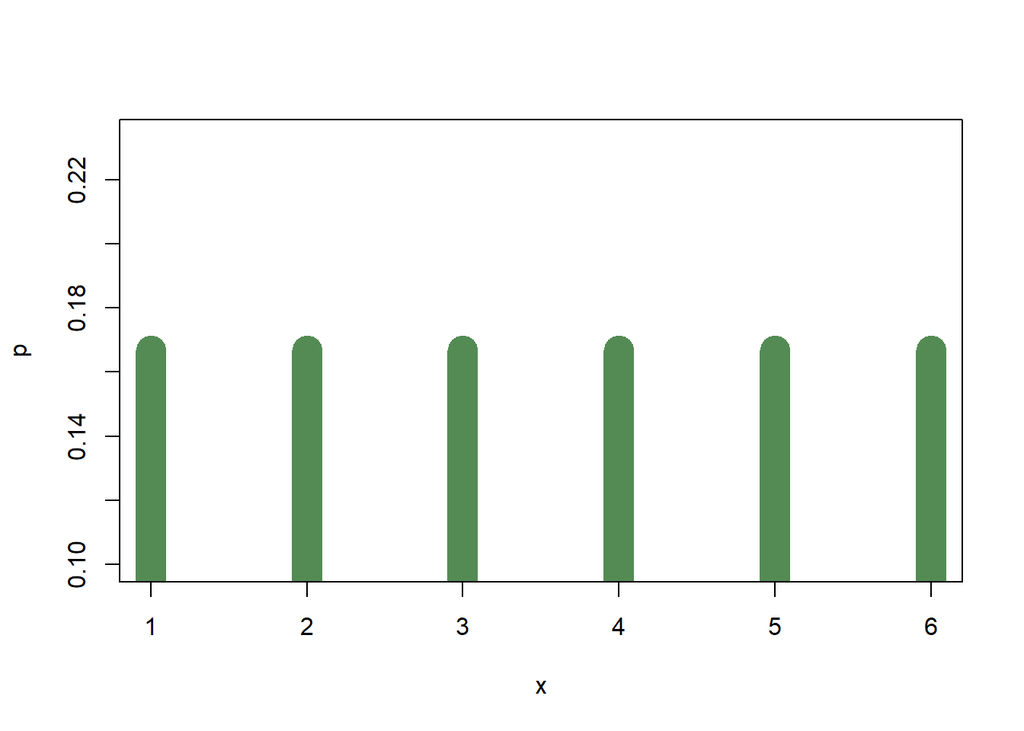

```r
x = seq(1,6,by=1)
p = rep(1/6,6)
plot(x=x, y=p, type="h", lwd=20, col='palegreen4')
```

# Binomiale

Adesso introduciamo un’altra variabile casuale discreta, che ha un ampio range di applicazioni: la distribuzione Binomiale.  
Questa distribuzione viene utilizzata quando ripetiamo in modo indipendente $n$-esperimenti, dove ogni singolo esperimento ha una probabilità di successo $p$ e una probabilità di fallimento $q=1-p$.

Per descrivere una distribuzione Binomiale, servono quindi due informazioni: *quanti* esperimenti ($n$) e *quale probabilità di successo* ($p$).  
Chiamiamo queste due informazioni *parametri* della distribuzione: al variare dei parametri, cambia la forma (ma non l’espressione analitica… la formula insomma) della distribuzione. In generale si indica con $Bin(n,p)$ una Binomiale di parametri $n$ e $p$.

La funzione di probabilità di una Binomiale è la seguente:
$$p(X=x) = \binom{n}{x} p^{x}q^{n-x} = \frac{n!}{x!(n-x)!}p^{x}(1-p)^{n-x}$$

$$\forall x=0,1,...,n$$

Supponiamo di aver inventato un nuovo farmaco che con probabilità 60% cura dall’HIV. Somministriamo il farmaco a 100 paziente.  
La distribuzione Binomiale permette di calcolare la probabilità di aver guarito con successo qualunque numero di questi 100 pazienti: nessuno, 1, 20, 50.. tutti e 100!

Se abbiamo a disposizione il grafico della $Bin(100, 0.6)$ possiamo farlo leggendo direttamente dal grafico, per ogni x da 0 a 100, l’altezza della rispettiva barra verticale. Se invece non abbiamo il grafico, possiamo farlo in modo analitico sostituendo nella formula x con il numero a cui siamo interessati.

Calcoliamo la probabilità di aver guarito esattamente la metà dei pazienti con entrambi i modi, analitico e grafico.  
Analitico:

$$p(X=50) = \binom{100}{50} p^{50}q^{100-50} = \frac{100!}{50!(100-50)!}0.6^{50}(1-0.6)^{100-50}$$

Questa probabilità è pari a circa 0.010337 = 1,0337%.

Graficamente:

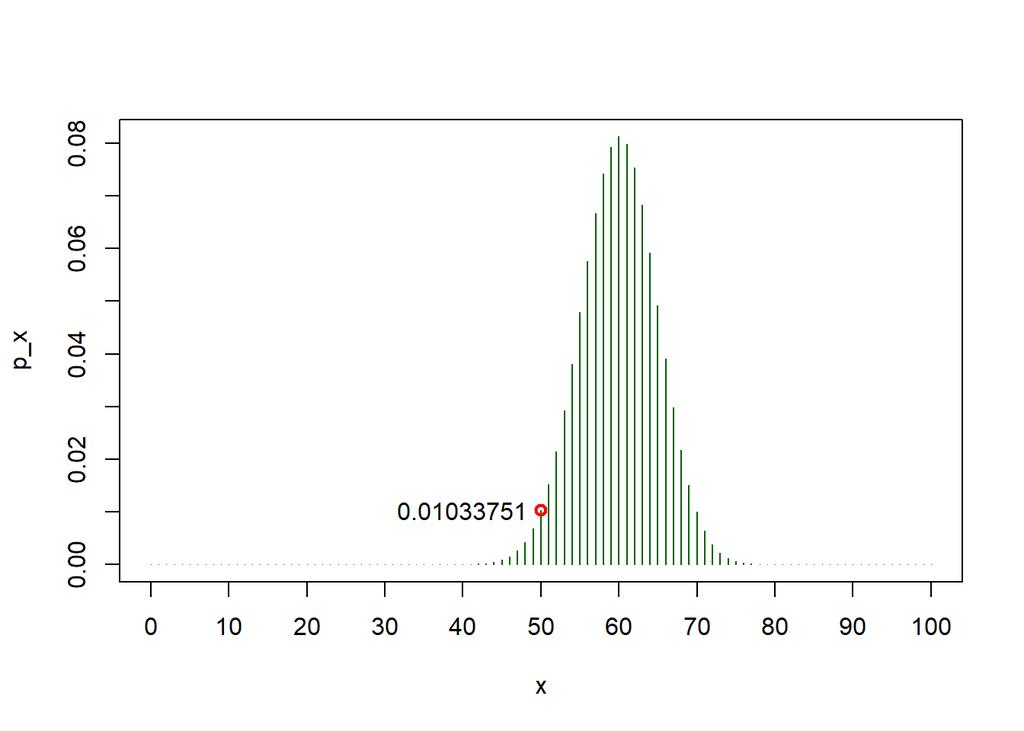

```r
x = seq(0, 100, by=1)
p_x = dbinom(x=x, size=100, prob=0.6)
plot(x=x, y=p_x, type='h', yaxt='n', xaxt='n', col='darkgreen')
axis(side=1, at = seq(0,100,10))
axis(side=2, at = seq(0, p_x[61], 0.01))
points(x=50, y=p_x[51], col='red', lwd=2)
text(labels="0.01033751", x=40, y=p_x[51])
```

Possiamo trarre diverse conclusioni dal grafico: è quasi 0 la probabilità di guarire meno di 40 pazienti, quasi certamente (con probabilità quasi 1) riusciremo a guarire tra i 40 e gli 80 pazienti, è quasi impossibile (prob. circa 0) guarire 80 o più pazienti. Calcolare in modo analitico queste probabilità con la funzione di probabilità, però, è molto scomodo quando $n \rightarrow +\infty$.
Infatti per calcolare la prob. di guarire 80 o più pazienti in modo analitico, dovrei calcolare con la formula della binomiale:
$$P(X \ge 80) = P(X=80) + P(X=81) + ... + P(X=100)$$

Per risolvere questo tipo di problemi abbiamo 2 metodi:  
1. Utilizzare la *funzione di Ripartizione* $F(x)=P(X \le x)$ 2. Utilizzare il *teorema del limite centrale*, che permette di approssimare una $Bin(n,p)$ con una Normale di media $\mu=np$ e deviazione standard $\sigma=\sqrt{np(1-p)}$.